# Modeling and Predictive Analysis of Human Activity Recognition data

## Overview

The purpose of this project is to create a model and predict how well an excersize is done.

## Data Source

Weightlifting excersize dataset is obtained from [here](http://groupware.les.inf.puc-rio.br/har). This dataset is collected by the researchers by using on-body sensing aproach,to investigate and predict how well an excersize is done. Six participants have done 10 sets of weightlifting excersizes in five different fashions, exactly according to the specification under the supervision of experienced weightlifters. The outcome of each excersize is classified as class, A, B, C, B or E. Only class A excersize matches the specific execution of the excersize and rest of the four are characterisitc of common mistakes. The dataset contains the time-series indicators from the on-body and dumbell sensors, in 0.5 second intervals. The avg, min, mas, std deviation are calculated for each window consisting of several overlapping intervals and stored in separate columns.

## Data Cleanup

This dataset contains two sets of in separate columns, one collected from sensors and others calcuated from the collected data. This has resulted in blank/missing values in many columns, without getting rid of that will make impossible to fit a model. Because of this, data clean-up is done to get rid of the null and unnecessary columns. This has resulted in reducing the number of variables from 160 to 53.

```r
dat <- read.csv("pml-training.csv", header = T, sep = ",", na.strings = c("","NA", "#DIV/0!"))
d1 <- dat[,colSums(is.na(dat)) < 10]
d1_f <- d1[, c(8:60)]
dim(d1_f)
```

```
## [1] 19622    53
```

## Pre-processing

Sixty percent of training dataset is partitioned to train a model and forty percent is used to validate the model.

```r
 library(caret)
 set.seed(3535)

 inTrain <- createDataPartition(y=d1_f$classe, p=0.6, list=FALSE)
 training <- d1_f[inTrain,]
 testing <- d1_f[-inTrain, ]
 dim(training)
```

```
## [1] 11776    53
```

```r
 dim(testing)
```

```
## [1] 7846   53
```

#### PCA Analysis

Firts, I tried to find out highly correlated variables and verify if merging them together will produce a better model by reducing the noise in data.

```r
 M <- abs(cor(training[, -53]))
 diag(M) <- 0
 ## which(M > 0.8, arr.ind = T)
 m <- which(M > 0.8, arr.ind = T)

dim(m)
```

```
## [1] 38  2
```

```r
print("Top 5 correlated variables")
```

```
## [1] "Top 5 correlated variables"
```

```r
m[1:5, ]
```

```
##                  row col
## yaw_belt           3   1
## total_accel_belt   4   1
## accel_belt_y       9   1
## accel_belt_z      10   1
## accel_belt_x       8   2
```

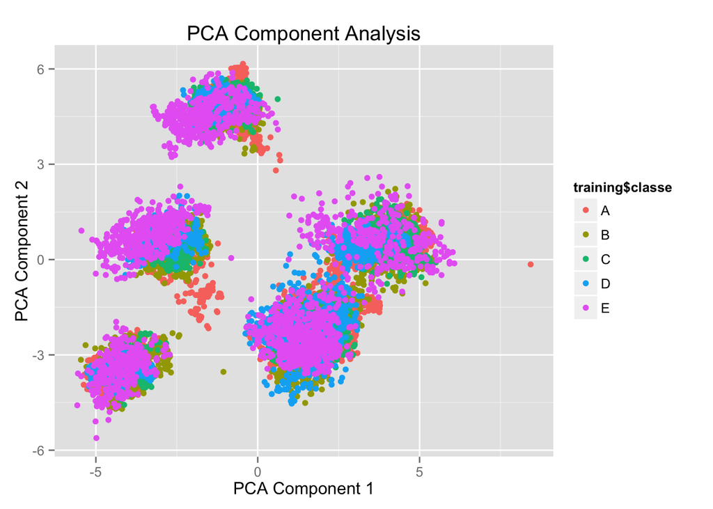

```r
 library(randomForest)
 preProc <- preProcess(training[, -53], method = "pca", pcaComp = 2)
 trainPC <- predict(preProc, training[, -53])
 ##plot(trainPC[,1], trainPC[,2])
 qplot(trainPC[,1], trainPC[,2], col=training$classe, xlab = "PCA Component 1", ylab = "PCA Component 2", main = "PCA Component Analysis")
```

```r
 fit_PC <- randomForest(training$classe ~ ., data = trainPC)
 testPC <- predict(preProc, testing[, -53])
 cm <- confusionMatrix(testing$classe, predict(fit_PC, testPC))
 cm$overall
```

```
##       Accuracy          Kappa  AccuracyLower  AccuracyUpper   AccuracyNull
##   4.435381e-01   2.949899e-01   4.325043e-01   4.546139e-01   2.986235e-01
## AccuracyPValue  McnemarPValue
##  1.788214e-161   3.822048e-03
```

Plotting the PCA components shows that we cannot predict the class based on these values.

The confusionMatrix shows that this model produce less than 50% accuracy, so it is not very helpful. This is expected as PCA analysis is more suitable for linear type models.

## Modeling and Prediction

This dataset has non-linear variable as result, we need to pick the methods suitable for creating non-linear models.

#### CART Method

Classification and Regression Tree method is tried first, as this is simplest to interpret. A gorup of variables are used to split the outcome in different group and then the groups are validated for homogeneity. If the groups are not homogenius furthe splits are tried unitl the group becomes homogeneous enough or the group becomes too small.

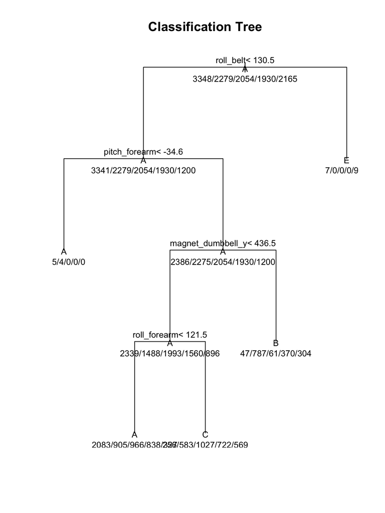

```r
library(rpart)
fit_rpart <- train(classe ~ . , data = training, method = "rpart")
plot(fit_rpart$finalModel, uniform=TRUE, main = "Classification Tree")
text(fit_rpart$finalModel, use.n=TRUE, all = TRUE, cex=.8)
```

#### Random Forest Method

Random forest method is widely used method to create models because of their high accuracy. In this method, both samples and variables are bootstraped at each split and then either vote or averages of outcomes are calulated in the end to generate the final model.

```r
library(randomForest)
fit1_rf <- randomForest(classe~., data=training)
fit1_rf$ntree; fit1_rf$mtry
```

```
## [1] 500
```

```
## [1] 7
```

#### Boosting Random Tree Method

```r
library(gbm)
fit_boost <- train(classe ~ ., method = "gbm", data = training, verbose = FALSE)
fit_boost$finalModel
```

```
## A gradient boosted model with multinomial loss function.
## 150 iterations were performed.
## There were 52 predictors of which 45 had non-zero influence.
```

#### Model Based prediction

In base model, it is assumed that data follows a specific probalistic model and a mdoel is tried based on optimal classifiers based on that model. The pros of this approach is that there might be some structure in the data collected in real life but the cons is that if the assumptions are very off then the prediction will fail.

```r
fit_lda <- train(classe ~ ., data = training, method = "lda")
## confusionMatrix(testing$classe, predict(fit_lda, testing))
```

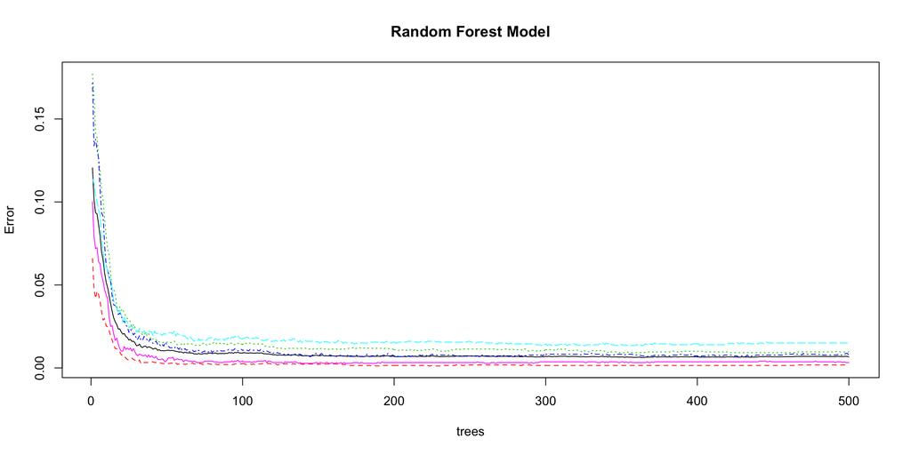

```r
plot(fit1_rf, main = "Random Forest Model")
```

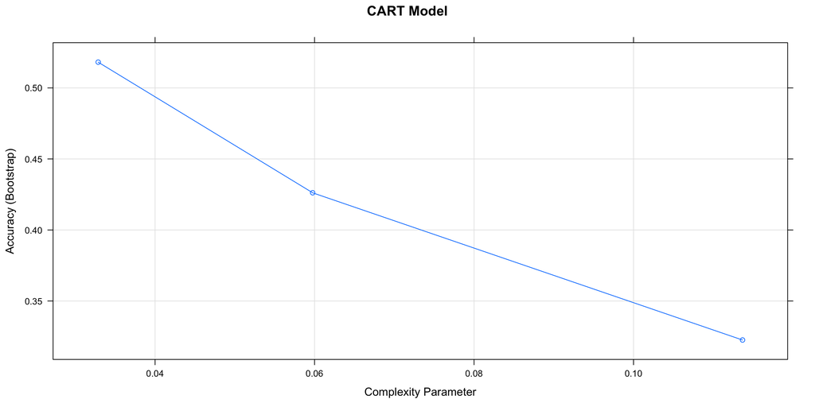

```r
plot(fit_rpart, main = "CART Model")
```

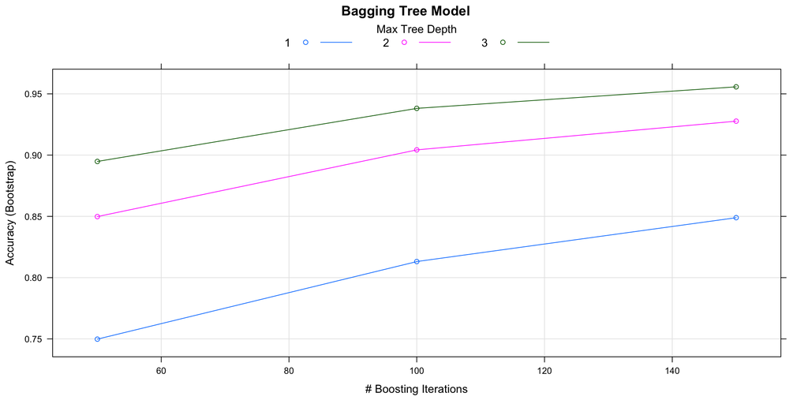

```r
plot(fit_boost, main = " Bagging Tree Model")
```

## Error Analysis

Below is the comparison of accuracy for all the methods used to create models in previous section.

```r
 cm <- confusionMatrix(testing$classe, predict(fit_PC, testPC))
 CM <- as.data.frame(cm$overall)
 names(CM)[1] <- "PCA w rf"

 cm1 <- confusionMatrix(testing$classe, predict(fit1_rf, testing))
 CM <- cbind(CM, cm1$overall)
 names(CM)[2] <- "rf"

 cm_lda <- confusionMatrix(testing$classe, predict(fit_lda, testing))
 CM <- cbind(CM, cm_lda$overall)
 names(CM)[3] <- "lda"

 cm_rpart <- confusionMatrix(testing$classe, predict(fit_rpart, testing))
 CM <- cbind(CM, cm_rpart$overall)
 names(CM)[4] <- "rpart"

 cm_boost <- confusionMatrix(testing$classe, predict(fit_boost, testing))
 CM <- cbind(CM, cm_boost$overall)
 names(CM)[5] <- "boost"

print("Printing accuracy comparision from each model")
```

```
## [1] "Printing accuracy comparision from each model"
```

```r
CM
```

```
##                     PCA w rf        rf          lda     rpart        boost
## Accuracy        4.439205e-01 0.9929901 6.994647e-01 0.4971960 9.599796e-01
## Kappa           2.954811e-01 0.9911315 6.198504e-01 0.3433944 9.493707e-01
## AccuracyLower   4.328856e-01 0.9908853 6.891832e-01 0.4860717 9.554046e-01
## AccuracyUpper   4.549971e-01 0.9947149 7.095979e-01 0.5083224 9.642087e-01
## AccuracyNull    2.986235e-01 0.2858782 2.922508e-01 0.5140199 2.856232e-01
## AccuracyPValue 2.714167e-162 0.0000000 0.000000e+00 0.9986156 0.000000e+00
## McnemarPValue   2.949237e-03       NaN 2.033929e-75       NaN 5.130961e-10
```

```r
print("Missclassification table for randomForest method")
```

```
## [1] "Missclassification table for randomForest method"
```

```r
cm1$table
```

```
##           Reference
## Prediction    A    B    C    D    E
##          A 2229    3    0    0    0
##          B   14 1502    2    0    0
##          C    0   13 1355    0    0
##          D    0    0   15 1269    2
##          E    0    0    1    5 1436
```

```r
pred1 <- predict(fit1_rf, testing)
x <- testing[which(testing$classe != pred1), c(53)]

print("Total number of mismatch values")
```

```
## [1] "Total number of mismatch values"
```

```r
length(x)
```

[output not shown]

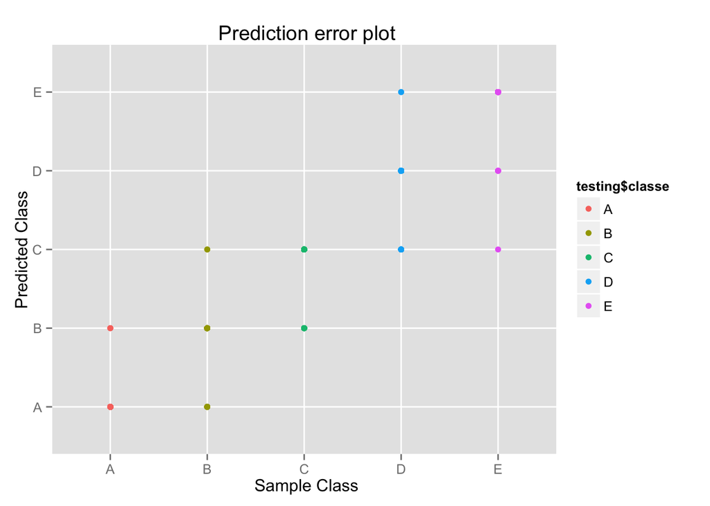

```r
qplot( testing$classe, pred1, color=testing$classe, xlab = " Sample Class", ylab = "Predicted Class", main = " Prediction error plot")
```

When regression tree model was generated using boosting method, the accuracy comes close to randomForest method.

## Conclusion

Random Forest model generated the maximum accuracy for the dataset used for this analysis.

## Credits:

Velloso, E.; Bulling, A.; Gellersen, H.; Ugulino, W.; Fuks, H. Qualitative Activity Recognition of Weight Lifting Exercises. Proceedings of 4th International Conference in Cooperation with SIGCHI (Augmented Human ’13) . Stuttgart, Germany: ACM SIGCHI, 2013. [Read more…](http://groupware.les.inf.puc-rio.br/har#ixzz3auylNvkl)

Class of Practical Machine Learning, Courtsey John Hopkins Univ., coursera.org